# Internship Report

## Kevin Zhang, Summer 2016

### Introduction

I spent this summer working as the single intern in the small GIT (geospatial information technology) department in the Fort Washington office of Michael Baker International (Baker). Baker is a consulting company that provides a wide range of technical solutions to an equally wide range of clients. I had mentioned to my manager Bud before the summer that I'd be interested in doing work relating to machine learning, and he said he had an ML project already in the works. So after the interview process I accepted his offer and looked forward to possibly working with and learning from machine learning experts. I arrived on the first day and the work environment was not really what I had expected. The GIT department was comprised of Bud and his full time software developer Idrissa. Bud also employed an offshore team in India, whose technical lead, Sijo, I would communicate with frequently. In our first meeting, Bud, Idrissa, and Sijo described to me their traffic modeling project with the New Jersey Department of Transportation, and it became apparent that none of them had much technical experience with machine learning.

The project was described to me as this: several dozen traffic stations are embedded underneath the New Jersey turnpike system. Each of these stations captures data on every vehicle that passes over it, including speed, vehicle classification, and a timestamp. Traffic volumes are a statistic of interest to traffic engineers and infrastructure planners, there's value in forecasting this based on the data we have.

Bud prefaced that project's direction was to be as a marketing tool to open the door for future contracts involving machine learning, as it would expose the NJDOT to the capabilities of ML. This meant that whatever work we'd do must have some sort of tangible deliverable, and my manager thought an iOS application for visualization of the model output would be a good option.

When I arrived, Sijo and his team had already put together a website to visualize the location of the traffic stations, and an AWS machine learning model. AWS has a machine learning tool that allows you to take a datatable stored in S3, specify columns for features and the target, and enter in some model parameters before it constructs a regression or classification model. It's basically a black box that takes some data and produces a trained model, but I noticed this abstraction had led Sijo's team to neglect preprocessing and feature selection.

I asked Bud why he insisted on using AWS ML. After seeing the model put together by the AWS black box, I was sure that a more transparently constructed model in Python would be better in the end, because of its ability to be finely tuned. And he replied that the terms, cloud technologies and AWS, are buzzwords that would resonate with decision makers at government agencies, and mentioning AWS would lead to a better first impression during the project demo. He said that officials at the NJDOT would only be generally, not technically, familiar with current technologies, so he predicted they would prefer hearing the usage of AWS ML over scikit-learn because of the familiarity of the term, AWS. But he still encouraged me to construct my own model, which is what I ended up doing, but this business decision to incorporate AWS was one of many business insights that Bud would give me over the summer. We often had long conversations where he described his projects as a GIT consultant, with emphasis put on the hype cycle. Our discussions enlightened me to the higher level business decisions that are crucial to becoming a successful technology consultant, which definitely wasn't typical of a software engineering internship and turned out to be one of the more valuable things I gained from my time at Baker.

So initially, I was intent on learning the basics of the AWS ecosystem. Bud offered early on to cover the fee of a AWS certification test if I wanted to pursue it. I ended up spending much of the first week watching video lectures covering an overview of the major services offered by AWS, which sort of set the tone for the rest of the internship. I didn't know anything about AWS or iOS entering the internship, and Bud didn't set any deadlines for me, so a lot of my time spent on the job was purely educational, which greatly benefitted me. Without the pressures of criteria to fill, or deadlines to meet, I was able to approach coding and learning about ML in a more relaxed manner that resulted in an enhancement of my appreciation and interest in computer science.

Initially, the overall aim of the project was to create an accurate regression model using machine learning to predict hourly traffic volumes through a given traffic station. However, the dataset we received only spanned from July 2013 to December 2015, which I originally perceived as too little data to make any extrapolation of future hourly volumes with a regression model inaccurate. I confirmed this later after preprocessing and seeing the mean stay roughly constant through the whole dataset. Therefore, I decided to instead steer the project towards constructing a regression model that would take the aggregate volumes across the available timespan and produce a function of several time parameters; the function representative of the hourly volumes at a particular traffic station in South Brunswick Township.

Some of what follows next is part of the report I gave to Bud and Idrissa as a part of my final presentation where I outlined my machine learning approach. I felt it was important to expose them to some of the technicalities in model construction and preprocessing of numerical data. I explained to them in detail the basic of regression, and considerations to take when dealing with overfitting and underfitting.

### Feature Selection

First I needed to determine which features, or columns to use in the training of the regression model. In other words, the end result of our machine learning model is a function $$f(z_0,z_1,z_2,...z_n) = volume_{hourly}$$ that accurately produces an hourly traffic volume given arguments $z_0...z_n$, and we need to choose which arguments $z$ train our model.

Among the columns present in the database, the only attribute that would be useful to predicting the hourly volume of traffic would be the timestamp of each car. However, the database contains individual records of vehicles, and since I wanted the hourly volume, I queried the database of vehicles that passed through the traffic station, grouping the cars into hourly bins, and chopped the timestamp into two pieces, the date and the time.

From the date I extracted several features, starting with the date itself, and more general features such as the day of week, week of the year, month, and season. From the time, we can glean the hour, whether the sun is up, and also whether its rush hour. My initial intuition for choosing from this pool was selecting the date, the hour, and the day of the week. The date, or day of the year, is the most specific denomination of the date section of the timestamp, and I felt that the day of the week was important to distinguish between weekdays and weekends, which would surely factor into traffic volumes. The hour of the day was a given inclusion. I did keep a mental note that these discrete features were as specific as the timestamp could produce, so if overfitting became an issue, then I would consider replacing the date with something more general, like week of the year. So to recap, the features I selected were the date, the hour, and day of the week.

Next I gave the type of variables some consideration. Hour of the day, date, and week day are all categorical variables. Regression models work with numerical variables, so this mismatch needed addressing. One solution I explored was one-hot encoding, which takes a categorical feature and creates a binary feature vector where each feature corresponds with one category. For example, day of the week is represented by a number $[0-6]$ (Sunday is 0), but after one-hot encoding, Sunday is $[1,0,0,0,0,0,0]$ and Monday is $[0,1,0,0,0,0,0]$.

However, the hour, day of the week, and date all possess an ordering of their discrete values. One-hot encoding is mainly for representing categorical features that have no inherent ordering, like red, white, and blue. Though it does make sense for Monday to be mapped to 1, Tuesday to 2, and so on. I explored both ways of representing my categorical features, and found that the model performed better with numerical encoding, over the one-hot encoding.

Early on, I compared the hour, day of week, date combination with other feature combinations on the AWS machine learning tool, and all the others performed worse, or had larger errors on average. Once I had figured out a good combination of features to represent the traffic volume function, I was done optimizing the AWS machine learning model, which would be incorporated alongside my Python regression model in an iOS visualization app.

### Data Preprocessing

The next step was preprocessing the data. Here is a plot of the original traffic volume data over time (07/02/2013 - 12/31/2015) each vertical line represents an hour's traffic volume:

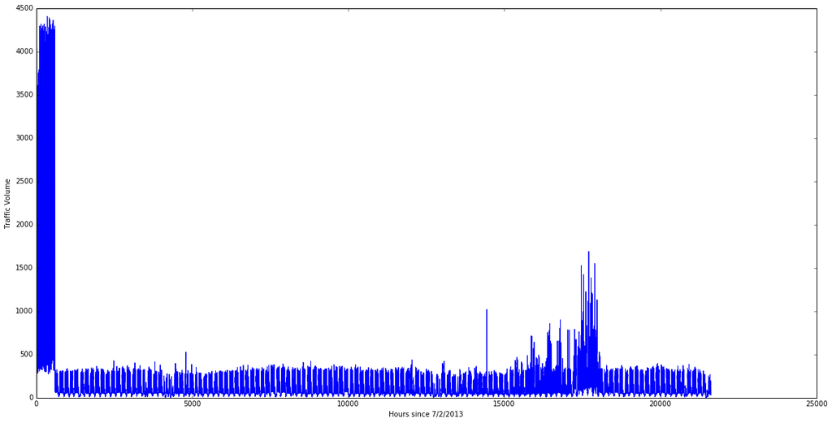

```python
%matplotlib inline
import numpy as np
import pandas as pd
import matplotlib.pyplot as plt

dataframe = pd.read_csv("original_data.csv")
y = np.array(dataframe['TRAFFIC_COUNT'])
plt.figure(figsize=(20,10))
plt.plot(y)
plt.xlabel("Hours since 7/2/2013")
plt.ylabel("Traffic Volume")
plt.show()
```

What's striking here is the traffic volumes of all of July 2013 (hour 0 - 650). We don't know what happened to the data there, but the range of values relative to the rest of the dataset obviously invalidate that month's data. Also notable is the spike in day traffic heading into and during summer 2015(hour 15000 - 18000), and the absence of such a spike during summer 2014.

Here is the same data as a scatter plot, this time with hourly traffic volume as a function of the day of year [0-365].

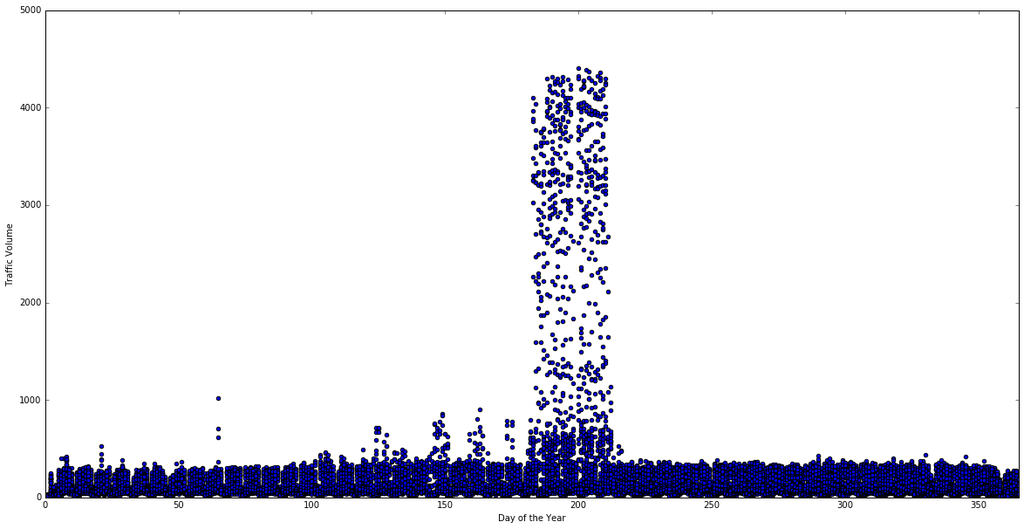

```python
x = np.array(dataframe['DAY_OF_YEAR'])
y = np.array(dataframe['TRAFFIC_COUNT'])
plt.figure(figsize=(20,10))
plt.scatter(x,y)
plt.axis([0,365,0,5000])
plt.xlabel("Day of the Year")
plt.ylabel("Traffic Volume")
plt.show()
```

The extreme values are more pronounced in this plot as each year is laid on top of one another. The floor of data points shows the vast majority of data points lying beneath 400, and the jutting column in the center is the aforementioned invalid data from July 2013. There are a few days with abnormally high traffic that might have been the result of an event or nearby road closure. There's no way that I can predict such events from solely the timestamp, so such anomalies should be removed.

A common practice in removing outliers is calculating the standard deviation across the whole dataset, and excluding any data points lie two or three standard deviations above or below the mean. This method wouldn't be a smart choice in this situation. The data from July 2013 would greatly skew the mean, and it also ignores that each hour of the day carries its own average traffic volume and standard deviation.

To illustrate each hour's distribution, consider the following scatterplot of the last four days in the dataset, with traffic volume plotted against the hour of the day.

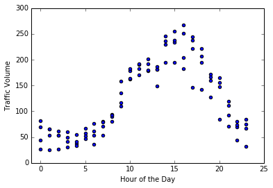

```python
df = dataframe.tail(n=96)
x = np.array(df['HR'])
y = np.array(df['TRAFFIC_COUNT'])

plt.scatter(x,y)
plt.axis([-1,25,0,300])
plt.xlabel("Hour of the Day")
plt.ylabel("Traffic Volume")
plt.show()
```

For South Brunswick Township, peak traffic times occur between noon and 6 PM, and understandably, less people are on the road at night.

To cater to each hour's traffic volume distribution, we treat them separately, determining independently their central tendency and standard deviation. As mentioned before, the arithmetic mean is not a good choice for centrality due to its sensitivity to extreme values (we have lots of extreme values). Therefore, the median is a far better statistic.

```python
Z_SCORE = 3

dataframe.sort_values(by='HR',inplace=True)
for hour in range(0,24):
    data = dataframe.loc[dataframe.HR==hour]
    d = np.abs(data['TRAFFIC_COUNT'] - np.median(data['TRAFFIC_COUNT']))
    median_distance = np.median(d)
    absolute_distance = d/median_distance if median_distance else 0
    dataframe.loc[dataframe.HR==hour] = data[absolute_distance<Z_SCORE]
dataframe = dataframe.dropna(how='any')
```

In the above code snippet, I sort the whole dataset by hour and treat each hour as its own dataframe. The array `data` is a pandas dataframe that contains the rows of data where the feature `HR == hour`, and `d` contains the absolute value of the difference between each row's traffic volume and the median traffic volume. From there, I determine the `median_distance` from the median traffic volume, and scale the distance vector `d` by the median distance. The second to last line removes all rows whose traffic volume is too far from the median `(> Z_SCORE * median_distance)`.

Here is the resulting data after removing outliers:

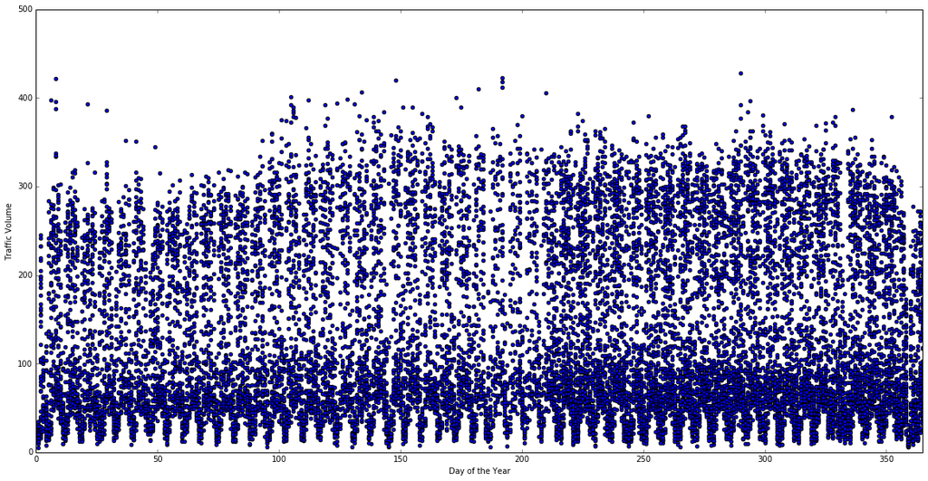

```python
x = np.array(dataframe['DAY_OF_YEAR'])
y = np.array(dataframe['TRAFFIC_COUNT'])
plt.figure(figsize=(20,10))
plt.scatter(x,y)
plt.axis([0,365,0,500])
plt.xlabel("Day of the Year")
plt.ylabel("Traffic Volume")
plt.show()
```

### Regression

After cleaning the data, I started to construct the regression model. For this, I used the `scikit-learn` package, which provides an assortment of models and tools for preprocessing and cross validation. I paid close attention to underfitting and overfitting by choosing a ridge regression model and carefully tuning its parameters.

A ridge regression model is similar to a simple least squares regression model (LSRL), but the ridge model includes a regularization parameter. An LSRL is constructed by minimizing the error function $$\sum_{i=1}^{n} (y_i - \hat y_i)^2 $$ while the ridge regression minimizes $$\sum_{i=1}^{n} (y_i - \hat y_{i})^2 + \lambda \sum_{j = 1}^{m} \beta_j$$
where $y_i$ is the i-th observation, $\hat y_i$ is the corresponding generated i-th prediction, $n$ is the number of predictions generated, $m$ is the number of terms in the regression function, and $\beta_j$ is the coefficient that corresponds to the j-th feature, $x_j$.

It should be noted that $$ \hat y_i = \sum_{j=1}^{n}{x_{j} \beta_j}$$

The term added in the ridge regression error function limits the size of the coefficients in the regression function, with the degree of the limitation hinged on the size of $\lambda$. By imposing a limit on the coefficients, the model avoids overfitting the training data. This regularization parameter $\lambda$ is one of the parameters I tuned during cross-validation.

Another model parameter I fiddled with was the highest degree polynomial to use in my regression function. `sci-kit learn` actually implements this step in the preprocessing phase. It takes a training instance of the model, in our case `[hour, day of week, date]`, and creates a new feature vector that contains all permutations of products of the features up to the degree specified. For example, for degree = 2, the feature vector would be $[hour^2, DOW^2, date^2, hour*DOW, DOW*date, hour*date, hour, DOW, date]$. From there, I would feed the feature vector into the model for training. Putting the determination of the polynomial degree in the preprocessing stage separated it from the cross-validation stage, which blocked me from autonomously trying each combination of degree polynomial and regularization parameter. I ended up manually trying combinations, which was not ideal.

I did run into an interesting issue when increasing the degree polynomial: when I decreased the regularization and increased the degree from 8 to 9, the error produced by the model dramatically increased, so much so that the coefficient of determination, or $R^2$ value, went from ~.90 to a negative value, meaning the regression model had become completely uncorrelated with the data. I investigated further and found that I might have run into my computer's threshold to succumbing to the curse of dimensionality (the feature vector for a 9th degree polynomial was over 100 features), or I encountered the result of an ill-conditioned design matrix, where a matrix used in the optimization process of the regression model becomes non-invertible, and the model cannot find coefficients from there forward.

### The Deliverable

I ended up putting the regression model I made in a flask server and hosted the server on an AWS EC2 instance my manager had already set up for the project. The flask server acts as a simple API that responds to HTTP GET requests, and takes arguments from the URL. For example, `http://www.wimnow.com:5001/success/0/223/3/2` grabs 2 days worth of predictions from the regression model starting from the 223rd day of the year (a Wednesday (corresponding to the 3)) at midnight (the 0).

I also wrote an iOS application that allows the user to input a date and amount of days of predictions, request the appropriate predictions from the server, and display them in a bar chart. I also allowed the user to specify whether to display predictions from the AWS machine learning model or the Python regression model.

### Conclusions

This was my first time doing paid work related to computer science, and I'd consider it a great success. The workplace environment was relaxed and I didn't collaborate much with other developers, which are definitely aspects of software engineering that I wish I had more of, but this internship solidified my interest in machine learning and widened my perspective. I gained a solid introduction into several major fields: machine learning, iOS development, and some back-end web dev.

Towards the end of the internship I realized that fitting a regression model might not have been the best approach, as the dataset of hourly traffic volumes is considered to be a time series. Time series analysis has a wholly separate toolkit for modeling and forecasting, but at that point I decided to just continue with the work I was doing for the sake of persistance and progress, over producing the optimal solution to the initial project objective.

I had a lot of fun writing this report in iPython, which I imagine is a widely used tool in the data science community. This project involved data manipulation, cleaning, modeling, visualization, and interpretation, which are all key components of work in data science. So hopefully I will find a position that leans towards this sort of work in the future!